[figure not shown]

# Tema 3: Introducción a R Studio

## **Parte 1: Introducción al programa**

### **Parte 1: Introducción al programa**

1. Abra el programa R Studio. Haga clic en el simbolo de carpeta que le permitirá abrir un archivo. Busque en la carpeta correspondiente el archivo “Tema 3 - Introducción a R.R” y presione Abrir/Open.

[figure not shown]

2. Una vez abierto, podrá ver 4 sectores del programa, tal como se muestra en la imagen.

[figure not shown]

   El primer sector es la zona marcada en ROJO: En esta zona se podrán ver tanto los archivos con código (como el script que acaba de abrir), como otros objetos (bases de datos, vectores, matrices, etc.) que tenga cargados en el programa. Los script (archivos .R) son los archivos donde se escribe el código, el cual permite registrar los comandos/procesos a ejecutar. En el script, para poner comentarios, es decir, texto que no requiere ser ejecutado por R Studio, se antepone el signo “#”. Para ejecutar un comando, se puede seleccionar las líneas correspondientes y presionar CNTR + ENTER. En el archivo “Tema 3 - Introducción a R.R”, se lee el siguiente texto. Los comandos a=10 y b=11, crearán 2 objetos, ambos objetos corresponden a números, llamados a y b, respectivamente, y con los valores 10 y 11, respectivamente. Seleccione las líneas con dichos comandos y presione CNTR + ENTER. Una vez que un objeto ha sido creado, o abierto (en el caso de que provenga de un archivo), se verá en la zona marcada en la imagen con color VERDE, que corresponde al ambiente/enviroment de trabajo. En este caso, ud. podrá ver los objetos a y b. Nótese que en R, a diferencia de Stata, por ejemplo, permite abrir varias bases de datos y objetos a la vez.

```r
# 1. Limpiar Abiente
a=10
b=11

rm(list = ls())
```

3. Seleccione el texto “rm(list = ls())” y presione CNTR + ENTER para ejecutar dicho comando. Al hacerlo, observarán que todos los objetos del ambiente fueron borrados. Es una buena práctica, comenzar los script con este comando para borrar cualquier objeto que pueda haber quedado abierto de una sesión anterior.
4. Agregue el signo “#” inmediatamente después del comando “rm(list = ls())” y describa en una frase, para qué se usa dicho comando. Luego, vuelva a crear a y b (ejecutando las líneas correspondientes) y a ejecutar el comando para limpiar el ambiente, seleccionando también el texto con su comentario. Al hacerlo, notará que este comando sigue funcionando correctamente; esto ocurre ya que el signo # le permite a R identificar que el texto comentado no corrresponde a un comando.
5. En la zona marcada en la imagen con color AZUL, se observa la consola. En esa se puede observar todos los comandos que uds. han ejecutado. Por último, en la zona marcada con color AMARILLO, se observa los Gráficos/Plots. Cuando use comandos para generar gráficos, podrá visualizarlos en esta zona. En esta misma zona también está el Help/Ayuda. Haga clic en dicho botón, y al lado de la lupa escriba “rm” y presione ENTER. Al hacerlo, encontrará la descripción del comando rm que acabamos de usar. Acá se explica que rm sirve para remover objetos del ambiente, que al indicar lista = se puede indicar una lista de los objetos a ser removidos, y al indicar list =ls() se remueven todos los objetos.

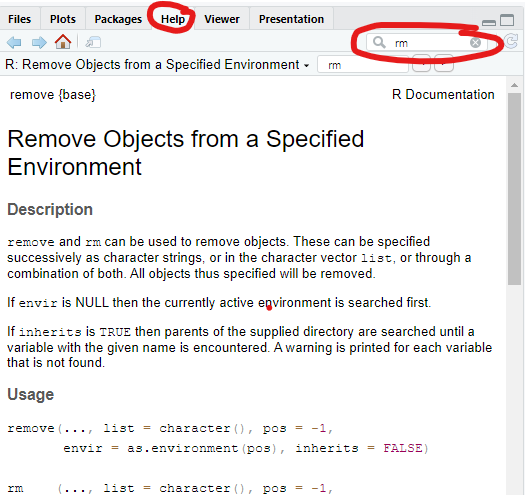

## **Parte 2: Estructura de datos en R**

### **Parte 2: Estructura de datos en R**

1. R es un software que funciona principalmente con objetos como escalares, vectores, matrices o arreglos, listas y bases de datos. Un escalar es un número, tal como los objetos a y b que recién creamos. Un vector es una fila o columna de datos. Un arreglo es un conjunto de numeros ordenados en 1 dimensión (vector), 2 dimensiones (matriz) o más. Una lista, como los vectores, tienen una solo dimensión, pero cada uno de sus elementos pueden ser de distinto tipo (por ejemplo, puede guardar un vector, una matriz y un escalar). Ejecute los siguientes comandos para crear un vector llamado c, y luego para visualizarlo en la consola.

```r
# 2. Crear un vector
c <- c(1,2,3,4,5)

#.3. Mostrar vector
c
```

2. Ejecute los siguientes comandos para crear una matriz llamada D, una matriz llamada E, y luego visualizarlas en la consola. Note que rbind, es un comando que junta vectores-fila (apilándo uno sobre otro), mientras que cbind junta vectores-columna (poniendo uno al lado del otro).

```r
# 4. Crear una matriz, apilando filas y visualizarla
D <- rbind(c(1,2,3),c(4,5,6))
D

# 5. Crear una matriz, juntando columnas, y visualizarla
E <- cbind(c(1,2,3),c(4,5,6))
E
```

3. Ejecute los siguientes comandos para crear una base de datos (dataframe)

```r
# 6. Crear base de datos F
F <- data.frame(nombre=c("Juan","Pedro", "Sofía","Andrea"),edad=c(12,10,11,9)) #las variables seran el nombre y la edad
F
```

4. En el ambiente/enviroment, haga clic en F para observar la base de datos.

[figure not shown]

5. Ejecute los siguientes comandos para agregar una nueva columna de datos a su data frame

```r
# 7. Agregar columna a base de datos F
F <- cbind(F, peso=c(35,27,28,25))
F
```

6. Ejecute los siguientes comandos para agregar una nueva fila de datos a su data frame

```r
# 8. Agregar fila a base de datos F
F <- rbind(F, c("Clara", 9,27))
F
```

7. Los datos guardados en los distintos objetos, pueden ser (1) numericos, (2) character (cadena, palabras), (3) factor (palabras, con opciones de dato pre-definidas), (4) logical (lógico): valores TRUE o FALSE que refieren a si ciertos datos cumplen ciertas condiciones, (5) pérdido/ NA (sin dato). Usa los siguientes comandos para crear los siguientes números y evaluar cuál es su tipo de dato.

```r
# 9. Crear objeto numéricos y conocer su tipo de datos
a=10
mode(a)
```

```r
# 10. Ver su tipo de datos de columna "nombre" de base de datos F
mode(F[,"nombre"])
mode(F[,2])
```

9. Agregaremos una variable a la base de datos que indicará el sexo de cada niña/o. Luego, la transformaremos en una variable factor y redefineremos los nombres de cada categoría o nivel. Para eso, ejecute los siguientes comandos.

```r
# 11. Agregar variable sexo, y evaluar el tipo de datos. H representará a los hombres y M a mujeres.
F <- cbind(F, sexo=c("H","H","M","M","M"))
F
mode(F[,"sexo"])

# 12. Modificar variable sexo, para que sea una variable factor, con los niveles "Hombre" y "Mujer"
F$sexo # Permite visualizar la variable sexo de la base F
F$sexo<-as.factor(F$sexo) #Tranforma la variable en factor
F$sexo # Permite visualizar la variable sexo de la base F
levels(F$sexo) # Visualiza los niveles
levels(F$sexo)<-c("Hombre", "Mujer") # Visualiza los niveles
levels(F$sexo) # Visualiza los niveles
F$sexo # Permite visualizar la variable sexo de la base F
```

24. Agregaremos una variable con valores lógicos a la base de datos que indicará si la/el niña/o es mayor de 10 años

```r
# 13. Agregar variable lógica que indique si es mayor de 10 años
F <- cbind(F, mayor_a_10=F$edad>10)
F
mode(F[,"mayor_a_10"])
```

11. Suponiendo que no tenemos el dato de la edad de Pedro, por lo cual, reemplazaremos su edad por NA. Luego, su recalculamos la variable mayor_a_10, Pedro también tendrá el valor NA

```r
# 14. Reemplazar un dato por NA
F$edad[F$nombre=="Pedro"] # Visualizar la edad de pedro
F$edad[F$nombre=="Pedro"] <- NA #Remplazarla por perdido
F$mayor_a10 <- F$edad>10 # Re-estimar la variable mayor_a_10
F # Visualizar base de datos
```